# Speech Commands

# What you are expected to do in this TP

This notebook contains the different blocks that allow you to train speech commands recognizers. The results provided with the features and classifiers above are far from optimal.

You are expected to explore various ways to improve their performance. Here are the main things to try:

- The parameters of the speech features such as the min/max frequency or window size are poorly chosen, look inside the resources mentioned in the class to find the best parameters for mel-filterbanks and MFCC.
- The logistic regression can be regularized in different ways (by controlling the C parameter) and you can try to find the best one
- The neural net proposed is a shallow neural net, far from the best you can train. You should try bigger, deeper architectures, different types of regularization, activation functions, learning rate and so on
- A standard way of improving generalization is to do mean-variance normalization on your data set. This is done by computing the mean and variance of each feature dimension on the entire training set, and then use it to normalize train, valid and test set
- The dataset provides noises samples, either artificial (pink, white noise) or real (dishes, bike) in the folder _background_noise. You can try augmenting your dataset by adding noise to the waveforms before computing the features
- The model is only trained on 300 examples per class, if your hardware allows it, try training on more examples
- Feel free to also experiment with different classifiers

You should find the best model by comparing validation accuracies. After you find your best model, finally test it on the test set and print the result. Comment on the results (best model, best features, classes that are the most difficult to recognize). The grade will not depend on the performance of the final system, but on how you experimented, tried different ideas, and comment on them.

Write your comments in Markdown cells, and send the ipython notebook as your assignment. Good luck!

[Documentation for logistic regression](http://scikit-learn.org/stable/modules/generated/sklearn.linear_model.LogisticRegression.html)

[Documentation for neural network](http://scikit-learn.org/stable/modules/generated/sklearn.neural_network.MLPClassifier.html)

First, we will add the second derivatives of the MFCC and see if the accelerations of changes of the MFCC coefficients contain any information and thus will give better performance.

```python
mfcc = spectral.Spectral(nfilt=20,
                    ncep=8,
                    do_dct=True,
                    lowerf=500,
                    upperf=5000,
                    alpha=0.6,
                    fs=framerate,
                    frate=100,
                    wlen=0.035,
                    nfft=512,
                    compression='log',
                    do_deltas=True,
                    do_deltasdeltas=True)

# Choose the feature function
feature_function = mfcc

start = time.time()
train_feats = np.asarray(pad(transform_wavs(train_wavs, feature_function)))
valid_feats = np.asarray(pad(transform_wavs(valid_wavs, feature_function)))
test_feats = np.asarray(pad(transform_wavs(test_wavs, feature_function)))
end = time.time()

print "Time to output features: " + str(end-start)
```

```
Time to output features: 29.1833240986
```

```python
len(train_feats[0])
```

```
2424
```

```python
#Logistic regression

logreg = sklearn.linear_model.LogisticRegression(verbose=1, tol=1e-3, random_state=777)

start = time.time()
logreg.fit(train_feats, train_labels)
end = time.time()

print "Training time of LogReg: " + str(end-start)

#Neural Network

neural_net = MLPClassifier(hidden_layer_sizes=(100,), validation_fraction = 0.2, early_stopping = False,
                                   verbose = True, random_state = 777, learning_rate='constant',
                                   learning_rate_init=0.01)

start = time.time()
neural_net.fit(train_feats, train_labels)
end = time.time()

print "Training time of NN: " + str(end-start)
```

```
[LibLinear]Training time of LogReg: 78.6633300781
Iteration 1, loss = 8.18629534
Iteration 2, loss = 2.36669005
Iteration 3, loss = 2.15227000
Iteration 4, loss = 2.01451341
Iteration 5, loss = 1.90380809
Iteration 6, loss = 1.81788490
Iteration 7, loss = 1.73219698
Iteration 8, loss = 1.64918803
Iteration 9, loss = 1.60321973
Iteration 10, loss = 1.57236098
Iteration 11, loss = 1.53222704
Iteration 12, loss = 1.51084331
Iteration 13, loss = 1.48494245
Iteration 14, loss = 1.47576913
Iteration 15, loss = 1.44913599
Iteration 16, loss = 1.42344852
Iteration 17, loss = 1.41338240
Iteration 18, loss = 1.37761196
Iteration 19, loss = 1.38801588
Iteration 20, loss = 1.37031433
Iteration 21, loss = 1.30775445
Iteration 22, loss = 1.32507617
Iteration 23, loss = 1.34393992
Iteration 24, loss = 1.26339170
Iteration 25, loss = 1.24810784
Iteration 26, loss = 1.21734089
Iteration 27, loss = 1.20182264
Iteration 28, loss = 1.24195127
Iteration 29, loss = 1.22665744
Iteration 30, loss = 1.22177526
Training loss did not improve more than tol=0.000100 for two consecutive epochs. Stopping.
Training time of NN: 3.66757178307
```

```python
print "Accuracy on valid set of the LogReg " + str(100*logreg.score(valid_feats, valid_labels)) + "%"
print "Accuracy on valid set of the NN " + str(100*neural_net.score(valid_feats, valid_labels)) + "%"
```

```
Accuracy on valid set of the LogReg 31.0%
Accuracy on valid set of the NN 43.9%
```

```python
print "Accuracy on test set of the LogReg " + str(100*logreg.score(test_feats, test_labels)) + "%"
print "Accuracy on test set of the NN " + str(100*neural_net.score(test_feats, test_labels)) + "%"
```

```
Accuracy on test set of the LogReg 30.4%
Accuracy on test set of the NN 41.6%
```

We can see that the performance using the mfcc output by adding the second mfcc coefficients derivatives has increased for the two algorithms from 30.8% to 31.0% for the LogReg and from 35.5% to 43.9% for the Neural network, we can notice that the performance has increased for the NN algorithm more noticably than for LogReg, this is because the NN algorithms has a lot parameters to adapt and then is more flexible to data.

It's worth also to note that the training time has increased a little bit since the size of each feature has also increased. To conclude, it's worth to add the second derivative coefficients to the features since it increases the performance greatly (specially for the NN algorithm) even if the training time increases.

I will test different range of low, large frequences to find the best performance. To respect the Nyquist-Shannon condition, the large frequence should not be higher than the frequence of sampling (which is 16kHz) then f_max$\le8000$. Those frequencies represent the range of frequencies that will be spanned by the filters.

```python
melfbanks = spectral.Spectral(nfilt=20,
                    ncep=0,
                    do_dct=False,
                    lowerf=500,
                    upperf=6000,
                    alpha=0.6,
                    fs=framerate,
                    frate=100,
                    wlen=0.035,
                    nfft=512,
                    compression='log',
                    do_deltas=False,
                    do_deltasdeltas=False)


feature_function = melfbanks

start = time.time()
train_feats = np.asarray(pad(transform_wavs(train_wavs, feature_function)))
valid_feats = np.asarray(pad(transform_wavs(valid_wavs, feature_function)))
test_feats = np.asarray(pad(transform_wavs(test_wavs, feature_function)))
end = time.time()

print "Time to output features: " + str(end-start)
```

```
Time to output features: 25.1906778812
```

```python
neural_net = MLPClassifier(hidden_layer_sizes=(100,), validation_fraction = 0.2, early_stopping = False,
                                   verbose = True, random_state = 777, learning_rate='constant',
                                   learning_rate_init=0.01)

start = time.time()
neural_net.fit(train_feats, train_labels)
end = time.time()

print "Training time of NN: " + str(end-start)
```

```
Iteration 1, loss = 19.69897829
Iteration 2, loss = 17.76158541
Iteration 3, loss = 4.98080267
Iteration 4, loss = 2.40606211
Iteration 5, loss = 2.39621682
Iteration 6, loss = 2.35939335
Iteration 7, loss = 2.39149812
Iteration 8, loss = 2.35841047
Iteration 9, loss = 2.36374893
Iteration 10, loss = 2.33919207
Iteration 11, loss = 2.34402158
Iteration 12, loss = 2.30832585
Iteration 13, loss = 2.32205431
Iteration 14, loss = 2.31778895
Iteration 15, loss = 2.30618825
Iteration 16, loss = 2.28799534
Iteration 17, loss = 2.27266168
Iteration 18, loss = 2.28768623
Iteration 19, loss = 2.28737195
Iteration 20, loss = 2.29511680
Training loss did not improve more than tol=0.000100 for two consecutive epochs. Stopping.
Training time of NN: 2.56718111038
```

```python
print "Accuracy on valid set of the NN " + str(100*neural_net.score(valid_feats, valid_labels)) + "%"
```

```
Accuracy on valid set of the NN 0.3%
```

```python
melfbanks = lambda (f_min,f_max) : spectral.Spectral(nfilt=20,
                    ncep=0,
                    do_dct=False,
                    lowerf=f_min,
                    upperf=f_max,
                    alpha=0.6,
                    fs=framerate,
                    frate=100,
                    wlen=0.035,
                    nfft=512,
                    compression='log',
                    do_deltas=False,
                    do_deltasdeltas=False)

mfcc = lambda (f_min,f_max) : spectral.Spectral(nfilt=20,
                    ncep=8,
                    do_dct=True,
                    lowerf=f_min,
                    upperf=f_max,
                    alpha=0.6,
                    fs=framerate,
                    frate=100,
                    wlen=0.035,
                    nfft=512,
                    compression='log',
                    do_deltas=True,
                    do_deltasdeltas=True)
```

```python
Frequencies = [(0,8000),(500,8000),(500,7000),(1000,7000),(1000,6500),(1000,6000),(500,5500),(500,6000),(100,7500)]
accuracy_log_reg_mfcc = []
accuracy_neural_net_mfcc = []
accuracy_log_reg_mfbank = []
accuracy_neural_net_mfbank = []
logreg = sklearn.linear_model.LogisticRegression(verbose=1, tol=1e-3, random_state=777)
neural_net = MLPClassifier(hidden_layer_sizes=(100,), validation_fraction = 0.2, early_stopping = False,
                                   verbose = True, random_state = 777, learning_rate='constant',
                                   learning_rate_init=0.01)
for i in range(len(Frequencies)):
    print('Window size = ', str(Frequencies[i]))
    #Features seletion
    feature_function = mfcc(Frequencies[i])
    start = time.time()
    train_feats = np.asarray(pad(transform_wavs(train_wavs, feature_function)))
    valid_feats = np.asarray(pad(transform_wavs(valid_wavs, feature_function)))
    test_feats = np.asarray(pad(transform_wavs(test_wavs, feature_function)))
    end = time.time()
    print "Time to output features: " + str(end-start)

    #Neural Network
    start = time.time()
    neural_net.fit(train_feats, train_labels)
    end = time.time()
    print "Training time NN: " + str(end-start)
    accuracy_neural_net_mfcc.append(100*neural_net.score(valid_feats, valid_labels))

for i in range(len(Frequencies)):
    print('Window size = ', str(Frequencies[i]))
    #Features seletion
    feature_function = melfbanks(Frequencies[i])
    start = time.time()
    train_feats = np.asarray(pad(transform_wavs(train_wavs, feature_function)))
    valid_feats = np.asarray(pad(transform_wavs(valid_wavs, feature_function)))
    test_feats = np.asarray(pad(transform_wavs(test_wavs, feature_function)))
    end = time.time()
    print "Time to output features: " + str(end-start)

    #Neural Network
    start = time.time()
    neural_net.fit(train_feats, train_labels)
    end = time.time()
    print "Training time NN: " + str(end-start)
    accuracy_neural_net_mfbank.append(100*neural_net.score(valid_feats, valid_labels))
```

```
('Window size = ', '(0, 8000)')
Time to output features: 34.9216082096
Iteration 1, loss = 9.43784020
Iteration 2, loss = 2.46940334
Iteration 3, loss = 2.11998867
Iteration 4, loss = 1.93624264
Iteration 5, loss = 1.76471040
Iteration 6, loss = 1.63231087
Iteration 7, loss = 1.51500500
Iteration 8, loss = 1.44880129
Iteration 9, loss = 1.38895121
Iteration 10, loss = 1.30675372
Iteration 11, loss = 1.28308147
Iteration 12, loss = 1.25989171
Iteration 13, loss = 1.24959889
Iteration 14, loss = 1.23813036
Iteration 15, loss = 1.16204870
Iteration 16, loss = 1.13024824
Iteration 17, loss = 1.12506957
Iteration 18, loss = 1.10118368
Iteration 19, loss = 1.17350324
Iteration 20, loss = 1.12993458
Iteration 21, loss = 1.07258981
Iteration 22, loss = 1.03463136
Iteration 23, loss = 0.98411762
Iteration 24, loss = 0.97917710
Iteration 25, loss = 0.95803129
Iteration 26, loss = 0.92940709
Iteration 27, loss = 0.93201597
Iteration 28, loss = 0.92192722
Iteration 29, loss = 0.91069340
Iteration 30, loss = 0.89568609
Iteration 31, loss = 0.89896563
Iteration 32, loss = 0.91436912
Iteration 33, loss = 0.85086014
Iteration 34, loss = 0.84381548
Iteration 35, loss = 0.83707569
Iteration 36, loss = 0.80593825
Iteration 37, loss = 0.80780265
Iteration 38, loss = 0.81390393
```

[output cut: 530 more lines]

```
Iteration 1, loss = 19.97453147
Iteration 2, loss = 9.49471928
Iteration 3, loss = 2.48784583
Iteration 4, loss = 2.40923316
Iteration 5, loss = 2.35551804
Iteration 6, loss = 2.35647982
Iteration 7, loss = 2.34443718
Iteration 8, loss = 2.33425900
Iteration 9, loss = 2.33412413
Iteration 10, loss = 2.30637856
Iteration 11, loss = 2.31967777
Iteration 12, loss = 2.31343271
Iteration 13, loss = 2.31737409
Training loss did not improve more than tol=0.000100 for two consecutive epochs. Stopping.
Training time NN: 1.18355488777
```

```python
print "Best accuracy performance for MFCC features is:", np.max(accuracy_neural_net_mfcc),\
                                "%, for the frequence range: ", Frequencies[np.argmax(accuracy_neural_net_mfcc)]

print "Best accuracy performance for mfbank features is:", np.max(accuracy_neural_net_mfbank),\
                                "%, for the frequence range: ", Frequencies[np.argmax(accuracy_neural_net_mfbank)]
```

```
Best accuracy performance for MFCC features is: 50.4 %, for the frequence range:  (0, 8000)
Best accuracy performance for mfbank features is: 12.3 %, for the frequence range:  (500, 6000)
```

```python
accuracy_neural_net_mfcc
```

```
[50.399999999999999,
 24.699999999999999,
 45.899999999999999,
 36.600000000000001,
 22.699999999999999,
 25.199999999999999,
 46.600000000000001,
 37.5,
 41.399999999999999]
```

```python
accuracy_neural_net_mfbank
```

```
[0.29999999999999999,
 0.10000000000000001,
 12.0,
 0.29999999999999999,
 0.10000000000000001,
 0.10000000000000001,
 0.29999999999999999,
 12.300000000000001,
 0.20000000000000001]
```

We can see that in general, the accuracy performance given by the mfbank features is very poor comparing it with the mfcc features (see the previous two cells), this is maybe because the speaker in our data is not unique, there are many speakers and MFCC works better since it's more appropriate in this case.

We can see that the best performance by the mfcc features using the neural network algorithm is given when we choose all the disponible range of frequencies (we don't filter any frequence), from 0 to 8000 Hz, this is because in our training data there are different gender and age speakers (child, female, male) so the range of frequence is large. Filtering an intervall of frequencies could limit the algorithm from training on different voice variancies which could give a poor performance.

Here, we will test different values of the window size.

```python
melfbanks = lambda x : spectral.Spectral(nfilt=20,
                    ncep=0,
                    do_dct=False,
                    lowerf=0,
                    upperf=8000,
                    alpha=0.6,
                    fs=framerate,
                    frate=100,
                    wlen=x,
                    nfft=512,
                    compression='log',
                    do_deltas=False,
                    do_deltasdeltas=False)

mfcc = lambda x : spectral.Spectral(nfilt=20,
                    ncep=8,
                    do_dct=True,
                    lowerf=0,
                    upperf=8000,
                    alpha=0.6,
                    fs=framerate,
                    frate=100,
                    wlen=x,
                    nfft=512,
                    compression='log',
                    do_deltas=True,
                    do_deltasdeltas=True)

A = [0.015,0.020,0.025,0.028,0.030,0.033,0.035,0.038,0.040,0.043]
accuracy_log_reg_mfbank_win = []
accuracy_neural_net_mfbank_win = []
accuracy_log_reg_mfcc_win = []
accuracy_neural_net_mfcc_win = []

logreg = sklearn.linear_model.LogisticRegression(verbose=1, tol=1e-3, random_state=777)
neural_net = MLPClassifier(hidden_layer_sizes=(100,), validation_fraction = 0.2, early_stopping = False,
                                   verbose = True, random_state = 777, learning_rate='constant',
                                   learning_rate_init=0.01)
for i in range(len(A)):
    print('Window size = ', str(A[i]))
    #Features seletion
    feature_function = mfcc(A[i])
    start = time.time()
    train_feats = np.asarray(pad(transform_wavs(train_wavs, feature_function)))
    valid_feats = np.asarray(pad(transform_wavs(valid_wavs, feature_function)))
    test_feats = np.asarray(pad(transform_wavs(test_wavs, feature_function)))
    end = time.time()
    print "Time to output features: " + str(end-start)

    #Logistic regression
    start = time.time()
    logreg.fit(train_feats, train_labels)
    end = time.time()
    print "Training time LogReg: " + str(end-start)
    accuracy_log_reg_mfcc_win.append(100*logreg.score(valid_feats, valid_labels))

    #Neural Network
    start = time.time()
    neural_net.fit(train_feats, train_labels)
    end = time.time()
    print "Training time NN: " + str(end-start)
    accuracy_neural_net_mfcc_win.append(100*neural_net.score(valid_feats, valid_labels))

for i in range(len(A)):
    print('Window size = ', str(A[i]))
    #Features seletion
    feature_function = melfbanks(A[i])
    start = time.time()
    train_feats = np.asarray(pad(transform_wavs(train_wavs, feature_function)))
    valid_feats = np.asarray(pad(transform_wavs(valid_wavs, feature_function)))
    test_feats = np.asarray(pad(transform_wavs(test_wavs, feature_function)))
    end = time.time()
    print "Time to output features: " + str(end-start)

    #Logistic regression
    start = time.time()
    logreg.fit(train_feats, train_labels)
    end = time.time()
    print "Training time LogReg: " + str(end-start)
    accuracy_log_reg_mfbank_win.append(100*logreg.score(valid_feats, valid_labels))

    #Neural Network
    start = time.time()
    neural_net.fit(train_feats, train_labels)
    end = time.time()
    print "Training time NN: " + str(end-start)
    accuracy_neural_net_mfbank_win.append(100*neural_net.score(valid_feats, valid_labels))
```

```
('Window size = ', '0.015')
Time to output features: 32.7137050629
[LibLinear]Training time LogReg: 76.7561290264
Iteration 1, loss = 9.52469039
Iteration 2, loss = 2.52531972
Iteration 3, loss = 2.29976795
Iteration 4, loss = 2.13579400
Iteration 5, loss = 1.95573691
Iteration 6, loss = 1.79140460
Iteration 7, loss = 1.68182549
Iteration 8, loss = 1.54091087
Iteration 9, loss = 1.45870417
Iteration 10, loss = 1.39755299
Iteration 11, loss = 1.35347808
Iteration 12, loss = 1.31612169
Iteration 13, loss = 1.31923910
Iteration 14, loss = 1.29046713
Iteration 15, loss = 1.26306198
Iteration 16, loss = 1.22234549
Iteration 17, loss = 1.18791929
Iteration 18, loss = 1.14950754
Iteration 19, loss = 1.13698280
Iteration 20, loss = 1.09850799
Iteration 21, loss = 1.08972122
Iteration 22, loss = 1.03318338
Iteration 23, loss = 1.02970332
Iteration 24, loss = 0.99467408
Iteration 25, loss = 0.97228795
Iteration 26, loss = 0.97951134
Iteration 27, loss = 0.95016025
Iteration 28, loss = 0.95656925
Iteration 29, loss = 0.93101899
Iteration 30, loss = 0.91539833
Iteration 31, loss = 0.89431909
Iteration 32, loss = 0.93165646
Iteration 33, loss = 0.91710343
Iteration 34, loss = 0.92636499
Training loss did not improve more than tol=0.000100 for two consecutive epochs. Stopping.
Training time NN: 3.91012001038
('Window size = ', '0.02')
```

[output cut: 570 more lines]

```
('Window size = ', '0.043')
Time to output features: 24.0149259567
[LibLinear]Training time LogReg: 99.1757261753
Iteration 1, loss = 20.19276081
Iteration 2, loss = 15.81832302
Iteration 3, loss = 2.43527037
Iteration 4, loss = 2.42072740
Iteration 5, loss = 2.38063862
Iteration 6, loss = 2.35867355
Iteration 7, loss = 2.34178532
Iteration 8, loss = 2.36464925
Iteration 9, loss = 2.34692364
Iteration 10, loss = 2.34441858
Training loss did not improve more than tol=0.000100 for two consecutive epochs. Stopping.
Training time NN: 0.907524824142
```

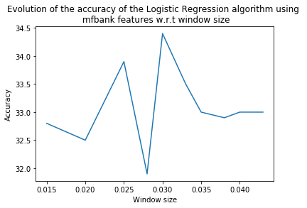

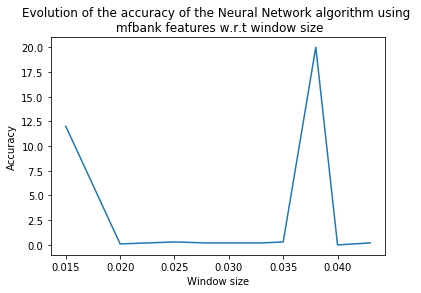

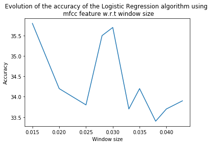

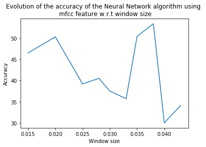

```python
plt.figure(1)
plt.title("Evolution of the accuracy of the Logistic Regression algorithm using \n mfbank features w.r.t window size")
plt.xlabel("Window size")
plt.ylabel("Accuracy")
plt.plot(A,accuracy_log_reg_mfbank_win)

plt.figure(2)
plt.title("Evolution of the accuracy of the Neural Network algorithm using \n mfbank features w.r.t window size")
plt.xlabel("Window size")
plt.ylabel("Accuracy")
plt.plot(A,accuracy_neural_net_mfbank_win)

plt.figure(3)
plt.title("Evolution of the accuracy of the Logistic Regression algorithm using \n mfcc feature w.r.t window size")
plt.xlabel("Window size")
plt.ylabel("Accuracy")
plt.plot(A,accuracy_log_reg_mfcc_win)

plt.figure(4)
plt.title("Evolution of the accuracy of the Neural Network algorithm using \n mfcc feature w.r.t window size")
plt.xlabel("Window size")
plt.ylabel("Accuracy")
plt.plot(A,accuracy_neural_net_mfcc_win)
```

```python
print "Best accuracy performance for LogReg using MFCC features is:", np.max(accuracy_log_reg_mfcc_win),\
                                "%, for the window size: ", A[np.argmax(accuracy_log_reg_mfcc_win)]

print "Best accuracy performance for NN using MFCC features is:", np.max(accuracy_neural_net_mfcc_win),\
                                "%, for the window size: ", A[np.argmax(accuracy_neural_net_mfcc_win)]
```

```
Best accuracy performance for LogReg using MFCC features is: 35.8 %, for the window size:  0.015
Best accuracy performance for NN using MFCC features is: 53.4 %, for the window size:  0.038
```

```python
print "Best accuracy performance for LogReg using mfbank features is:", np.max(accuracy_log_reg_mfbank_win),\
                                "%, for the window size: ", A[np.argmax(accuracy_log_reg_mfbank_win)]

print "Best accuracy performance for NN using mfbank features is:", np.max(accuracy_neural_net_mfbank_win),\
                                "%, for the window size: ", A[np.argmax(accuracy_neural_net_mfbank_win)]
```

```
Best accuracy performance for LogReg using mfbank features is: 34.4 %, for the window size:  0.03
Best accuracy performance for NN using mfbank features is: 20.0 %, for the window size:  0.038
```

```python
accuracy_log_reg_mfcc_win
```

```
[35.799999999999997,
 34.200000000000003,
 33.800000000000004,
 35.5,
 35.699999999999996,
 33.700000000000003,
 34.200000000000003,
 33.399999999999999,
 33.700000000000003,
 33.900000000000006]
```

```python
accuracy_log_reg_mfbank_win
```

```
[32.800000000000004,
 32.5,
 33.900000000000006,
 31.900000000000002,
 34.399999999999999,
 33.5,
 33.0,
 32.899999999999999,
 33.0,
 33.0]
```

Next, we will use only mfcc features since they have proved that they give better performance than the mfbank features. First, we will use a mean-variance normalization to see if the performance improves.

```python
mfcc = spectral.Spectral(nfilt=20,
                    ncep=8,
                    do_dct=True,
                    lowerf=0,
                    upperf=8000,
                    alpha=0.6,
                    fs=framerate,
                    frate=100,
                    wlen=0.038,
                    nfft=512,
                    compression='log',
                    do_deltas=True,
                    do_deltasdeltas=True)
```

```python
feature_function = mfcc

start = time.time()
train_feats = np.asarray(pad(transform_wavs(train_wavs, feature_function)))
valid_feats = np.asarray(pad(transform_wavs(valid_wavs, feature_function)))
test_feats = np.asarray(pad(transform_wavs(test_wavs, feature_function)))
end = time.time()

print "Time to output features: " + str(end-start)
```

```
Time to output features: 31.3467230797
```

```python
from sklearn import preprocessing
train_feats = preprocessing.scale(train_feats)
valid_feats = preprocessing.scale(valid_feats)
test_feats = preprocessing.scale(test_feats)
```

```python
#Logistic regression

logreg = sklearn.linear_model.LogisticRegression(verbose=1, tol=1e-3, random_state=777)

start = time.time()
logreg.fit(train_feats, train_labels)
end = time.time()

print "Training time: " + str(end-start)

#Neural Network
neural_net = MLPClassifier(hidden_layer_sizes=(100,), validation_fraction = 0.2, early_stopping = False,
                                   verbose = True, random_state = 777, learning_rate='constant',
                                   learning_rate_init=0.01)

start = time.time()
neural_net.fit(train_feats, train_labels)
end = time.time()

print "Training time of NN: " + str(end-start)
```

```
[LibLinear]Training time: 70.0124249458
Iteration 1, loss = 6.44318751
Iteration 2, loss = 3.27163775
Iteration 3, loss = 1.97220379
Iteration 4, loss = 1.10557641
Iteration 5, loss = 0.77713053
Iteration 6, loss = 0.60532702
Iteration 7, loss = 0.47437533
Iteration 8, loss = 0.44499094
Iteration 9, loss = 0.32823674
Iteration 10, loss = 0.26096185
Iteration 11, loss = 0.19401136
Iteration 12, loss = 0.17066744
Iteration 13, loss = 0.27442741
Iteration 14, loss = 0.28999066
Iteration 15, loss = 0.17753628
Training loss did not improve more than tol=0.000100 for two consecutive epochs. Stopping.
Training time of NN: 1.98373889923
```

```python
print "Accuracy on valid set of the LogReg using normalized \
mfcc features " + str(100*logreg.score(valid_feats, valid_labels)) + "%"
print "Accuracy on valid set of the NN using normalized \
mfcc features " + str(100*neural_net.score(valid_feats, valid_labels)) + "%"
```

```
Accuracy on valid set of the LogReg using normalized mfcc features 26.0%
Accuracy on valid set of the NN using normalized mfcc features 61.4%
```

```python
print "Accuracy on test set of the LogReg using normalized \
mfcc features " + str(100*logreg.score(test_feats, test_labels)) + "%"
print "Accuracy on test set of the NN using normalized \
mfcc features " + str(100*neural_net.score(test_feats, test_labels)) + "%"
```

```
Accuracy on test set of the LogReg using normalized mfcc features 26.7%
Accuracy on test set of the NN using normalized mfcc features 58.7%
```

As expected, the performance has increased for the NN by almost 10%, while it has decreased for the LogReg algorithm by almost 8%. We can say that the normalization is good for Neural network while it's not for Logistic Regression. This is because the default activation function of the neural network is ReLu which don't saturate for large values and then by normalizing the features is still don't saturate. Unlike LogReg where the sigmoid function is very sensitive to changes in features values since it contains an exponential function which could change the performance badly.

```python
C = [0.001,0.006,0.01,0.02,0.05,0.1,0.4,1,5,10,30,100]
#Logistic regression
accuracy = []
for i in range(len(C)):
    logreg = sklearn.linear_model.LogisticRegression(verbose=1, tol=1e-3,C=C[i],random_state=777)
    start = time.time()
    logreg.fit(train_feats, train_labels)
    end = time.time()
    accuracy.append(100*logreg.score(valid_feats, valid_labels))
```

```
[LibLinear][LibLinear][LibLinear][LibLinear][LibLinear][LibLinear][LibLinear][LibLinear][LibLinear][LibLinear][LibLinear]
```

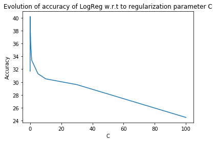

```python
plt.plot(C,accuracy)
plt.title('Evolution of accuracy of LogReg w.r.t to regularization parameter C')
plt.xlabel('C')
plt.ylabel('Accuracy')
plt.show()
```

```python
accuracy
```

```
[31.699999999999999,
 38.299999999999997,
 39.900000000000006,
 40.200000000000003,
 39.300000000000004,
 38.0,
 35.699999999999996,
 33.399999999999999,
 31.300000000000001,
 30.5,
 29.599999999999998,
 24.5]
```

```python
print "Best accuracy performance on valid set for LogReg using regularization features is:", np.max(accuracy),\
                                "%,for C=: ", C[np.argmax(accuracy)]
```

```
Best accuracy performance on valid set for LogReg using regularization features is: 40.2 %,for C=:  0.02
```

```python
logreg = sklearn.linear_model.LogisticRegression(verbose=1, tol=1e-3,C=0.02,random_state=777)
start = time.time()
logreg.fit(train_feats, train_labels)
end = time.time()
```

```
[LibLinear]
```

```python
print "Accuracy on test set of the LogReg using the best parameters is \
" + str(100*logreg.score(test_feats, test_labels)) + "%"
```

```
Accuracy on test set of the LogReg using the best parameters is 37.4%
```

The best performance is given by C = 0.02 which is a smaller value and correspond to a strong regularization $\lambda$ = 50. The performance on test data is good but still smaller than the performance given by the shallow NN.

Next, we will play with the parameters/structure of the MLP algorithm.

1 Hidden layer architecture

```python
accuracy_ = []
alpha = [0.00001,0.0001,0.0005,0.001,0.005,0.01,0.05,0.1,0.5,1,1.5]
for i in range(len(alpha)):
    print('Alpha = ', alpha[i])
    neural_net = MLPClassifier(hidden_layer_sizes=(100,),activation='relu', validation_fraction = 0.2, early_stopping = False,
                                   verbose = True,alpha = alpha[i], random_state = 777, learning_rate='constant',
                                   learning_rate_init=0.001)
    neural_net.fit(train_feats, train_labels)
    accuracy_.append(100*neural_net.score(valid_feats, valid_labels))
```

```
('Alpha = ', 1e-05)
Iteration 1, loss = 2.12063572
Iteration 2, loss = 1.27219906
Iteration 3, loss = 0.94970956
Iteration 4, loss = 0.75595962
Iteration 5, loss = 0.65100001
Iteration 6, loss = 0.57211309
Iteration 7, loss = 0.48845598
Iteration 8, loss = 0.43893877
Iteration 9, loss = 0.36426352
Iteration 10, loss = 0.32099742
Iteration 11, loss = 0.28609218
Iteration 12, loss = 0.25279279
Iteration 13, loss = 0.22630858
Iteration 14, loss = 0.19282345
Iteration 15, loss = 0.16982294
Iteration 16, loss = 0.15691810
Iteration 17, loss = 0.13917583
Iteration 18, loss = 0.12433153
Iteration 19, loss = 0.11135272
Iteration 20, loss = 0.09777778
Iteration 21, loss = 0.08617581
Iteration 22, loss = 0.07752412
Iteration 23, loss = 0.06763624
Iteration 24, loss = 0.06283869
Iteration 25, loss = 0.05782341
Iteration 26, loss = 0.05229222
Iteration 27, loss = 0.04696806
Iteration 28, loss = 0.04302711
Iteration 29, loss = 0.03927007
Iteration 30, loss = 0.03655499
Iteration 31, loss = 0.03433437
Iteration 32, loss = 0.03169808
Iteration 33, loss = 0.02992215
Iteration 34, loss = 0.02798788
Iteration 35, loss = 0.02612275
Iteration 36, loss = 0.02538354
Iteration 37, loss = 0.02341887
Iteration 38, loss = 0.02187873
Iteration 39, loss = 0.02083931
```

[output cut: 1009 more lines]

```
Iteration 43, loss = 0.41205089
Iteration 44, loss = 0.40549467
Iteration 45, loss = 0.39510164
Iteration 46, loss = 0.39176722
Iteration 47, loss = 0.38537407
Iteration 48, loss = 0.37936040
Iteration 49, loss = 0.37646136
Iteration 50, loss = 0.37101259
Iteration 51, loss = 0.37175873
Iteration 52, loss = 0.37131797
Iteration 53, loss = 0.36695648
Iteration 54, loss = 0.37376896
Iteration 55, loss = 0.38047200
Iteration 56, loss = 0.45660141
Training loss did not improve more than tol=0.000100 for two consecutive epochs. Stopping.
```

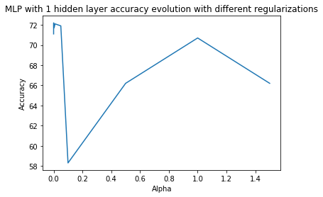

```python
plt.plot(alpha,accuracy_)
plt.title('MLP with 1 hidden layer accuracy evolution with different regularizations')
plt.xlabel('Alpha')
plt.ylabel('Accuracy')
plt.show()
```

```python
print "Best accuracy performance for NN using 1 hidden layer:", np.max(accuracy_),\
                                "%, for a regulaziation\n alpha= ",alpha[np.argmax(accuracy_)]
```

```
Best accuracy performance for NN using 1 hidden layer: 72.2 %, for a regulaziation
 alpha=  0.0005
```

```python
print "Accuracy on test set of the NN 1 hidden layer using alpha = 0.0005 is : \
" + str(100*neural_net.score(test_feats, test_labels)) + "%"
```

```
Accuracy on test set of the NN 1 hidden layer using alpha = 0.0005 is : 66.8%
```

3 hidden Layers architecture

```python
accuracy = []
alpha = [0.00001,0.0001,0.0005,0.001,0.005,0.01,0.05,0.1,0.5,1,1.5]
for i in range(len(alpha)):
    print('Alpha = ', alpha[i])
    neural_net = MLPClassifier(hidden_layer_sizes=(100,40,30),activation='relu', validation_fraction = 0.2, early_stopping = False,
                                   verbose = True,alpha = alpha[i], random_state = 777, learning_rate='constant',
                                   learning_rate_init=0.001)
    neural_net.fit(train_feats, train_labels)
    accuracy.append(100*neural_net.score(valid_feats, valid_labels))
```

[output not shown]

[output cut: 484 more lines]

```
Iteration 27, loss = 0.58139500
Iteration 28, loss = 0.55104853
Iteration 29, loss = 0.52433500
Iteration 30, loss = 0.51833475
Iteration 31, loss = 0.51365753
Iteration 32, loss = 0.50096231
Iteration 33, loss = 0.50676237
Iteration 34, loss = 0.50240244
Iteration 35, loss = 0.49906029
Iteration 36, loss = 0.48848181
Iteration 37, loss = 0.47669923
Iteration 38, loss = 0.48983330
Iteration 39, loss = 0.51115323
Iteration 40, loss = 0.51568865
Training loss did not improve more than tol=0.000100 for two consecutive epochs. Stopping.
```

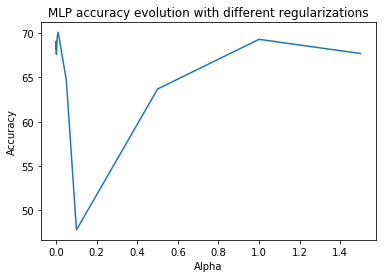

```python
plt.plot(alpha,accuracy)
plt.title('MLP accuracy evolution with different regularizations')
plt.xlabel('Alpha')
plt.ylabel('Accuracy')
plt.show()
```

```python
print "Best accuracy performance for NN using 3 hidden layer:", np.max(accuracy),\
                                "%, for a regulaziation\n alpha= ",alpha[np.argmax(accuracy)]
```

```
Best accuracy performance for NN using 3 hidden layer: 70.1 %, for a regulaziation
 alpha=  0.01
```

```python
print "Accuracy on test set of the NN 3 hidden layer using alpha = 0.01 is : \
" + str(100*neural_net.score(test_feats, test_labels)) + "%"
```

```
Accuracy on test set of the NN 3 hidden layer using alpha = 0.01 is : 64.6%
```

```python
accuracy1 = []
alpha = [0.00001,0.0001,0.0005,0.001,0.005,0.01,0.05,0.1,0.5,1,1.5,1.7,2]
for i in range(len(alpha)):
    print('Alpha = ', alpha[i])
    neural_net = MLPClassifier(hidden_layer_sizes=(30,20,15),activation='relu', validation_fraction = 0.2, early_stopping = False,
                                   verbose = True,alpha = alpha[i], random_state = 777, learning_rate='constant',
                                   learning_rate_init=0.001)
    neural_net.fit(train_feats, train_labels)
    accuracy1.append(100*neural_net.score(valid_feats, valid_labels))
```

```
('Alpha = ', 1e-05)
Iteration 1, loss = 2.24964906
Iteration 2, loss = 1.98797437
Iteration 3, loss = 1.81318764
Iteration 4, loss = 1.66731438
Iteration 5, loss = 1.50194283
Iteration 6, loss = 1.36840327
Iteration 7, loss = 1.22225729
Iteration 8, loss = 1.08625913
Iteration 9, loss = 0.96481062
Iteration 10, loss = 0.85815651
Iteration 11, loss = 0.80026389
Iteration 12, loss = 0.72898243
Iteration 13, loss = 0.66056235
Iteration 14, loss = 0.60601015
Iteration 15, loss = 0.56564612
Iteration 16, loss = 0.52659491
Iteration 17, loss = 0.48852747
Iteration 18, loss = 0.45675952
Iteration 19, loss = 0.42871870
Iteration 20, loss = 0.39752830
Iteration 21, loss = 0.37600050
Iteration 22, loss = 0.35400682
Iteration 23, loss = 0.32815316
Iteration 24, loss = 0.31483968
Iteration 25, loss = 0.28876011
Iteration 26, loss = 0.27266428
Iteration 27, loss = 0.25627902
Iteration 28, loss = 0.23782962
Iteration 29, loss = 0.22121338
Iteration 30, loss = 0.20518694
Iteration 31, loss = 0.19292772
Iteration 32, loss = 0.18537244
Iteration 33, loss = 0.17640826
Iteration 34, loss = 0.16578211
Iteration 35, loss = 0.15318458
Iteration 36, loss = 0.14184119
Iteration 37, loss = 0.13332711
Iteration 38, loss = 0.12630347
Iteration 39, loss = 0.12003183
```

[output cut: 947 more lines]

```
Iteration 33, loss = 0.63104603
Iteration 34, loss = 0.62051476
Iteration 35, loss = 0.61587529
Iteration 36, loss = 0.61493073
Iteration 37, loss = 0.60247445
Iteration 38, loss = 0.59865747
Iteration 39, loss = 0.59028180
Iteration 40, loss = 0.57095056
Iteration 41, loss = 0.56969104
Iteration 42, loss = 0.55920907
Iteration 43, loss = 0.55582579
Iteration 44, loss = 0.56444246
Iteration 45, loss = 0.57348890
Iteration 46, loss = 0.56296501
Training loss did not improve more than tol=0.000100 for two consecutive epochs. Stopping.
```

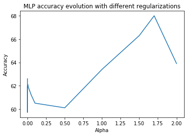

```python
plt.plot(alpha,accuracy1)
plt.title('MLP accuracy evolution with different regularizations')
plt.xlabel('Alpha')
plt.ylabel('Accuracy')
plt.show()
```

```python
print "Best accuracy performance for NN using 3 hidden layer with less units:", np.max(accuracy1),\
                                "%, for a\n regulaziation alpha= ",alpha[np.argmax(accuracy1)]
```

```
Best accuracy performance for NN using 3 hidden layer with less units: 68.0 %, for a
 regulaziation alpha=  1.7
```

```python
print "Accuracy on test set of the NN 3 hidden layer with less units using alpha = 1.7 is : \
" + str(100*neural_net.score(test_feats, test_labels)) + "%"
```

```
Accuracy on test set of the NN 3 hidden layer with less units using alpha = 1.7 is : 63.0%
```

Now, we will increase the training set and see if the performance increases to 2000 per class.

```python
feature_function = mfcc

start = time.time()
train_feats = np.asarray(pad(transform_wavs(train_wavs, feature_function)))
valid_feats = np.asarray(pad(transform_wavs(valid_wavs, feature_function)))
test_feats = np.asarray(pad(transform_wavs(test_wavs, feature_function)))
end = time.time()

print "Time to output features: " + str(end-start)
```

```
Time to output features: 115.852262974
```

```python
#Logistic regression

logreg = sklearn.linear_model.LogisticRegression(verbose=1, tol=1e-3, random_state=777)

start = time.time()
logreg.fit(train_feats, train_labels)
end = time.time()

print "Training time of LogReg: " + str(end-start)

#Neural Network
```

```
[LibLinear]Training time of LogReg: 620.580856085
```

```python
print "Accuracy on validation set of the LogReg using the best parameters is \
" + str(100*logreg.score(valid_feats, valid_labels)) + "%"
```

```
Accuracy on validation set of the LogReg using the best parameters is 39.6%
```

```python
print "Accuracy on test set of the LogReg using the best parameters is \
" + str(100*logreg.score(test_feats, test_labels)) + "%"
```

```
Accuracy on test set of the LogReg using the best parameters is 38.8%
```

```python
from sklearn import preprocessing
train_feats = preprocessing.scale(train_feats)
valid_feats = preprocessing.scale(valid_feats)
test_feats = preprocessing.scale(test_feats)

neural_net = MLPClassifier(hidden_layer_sizes=(100,),activation='relu', validation_fraction = 0.2, early_stopping = False,
                                   verbose = True,alpha = 0.0005, random_state = 777, learning_rate='constant',
                                   learning_rate_init=0.001)
neural_net.fit(train_feats, train_labels)
100*neural_net.score(valid_feats, valid_labels)
```

```
Iteration 1, loss = 1.27261891
Iteration 2, loss = 0.71602279
Iteration 3, loss = 0.55735731
Iteration 4, loss = 0.47177006
Iteration 5, loss = 0.42261391
Iteration 6, loss = 0.37378113
Iteration 7, loss = 0.32924672
Iteration 8, loss = 0.30441275
Iteration 9, loss = 0.28674682
Iteration 10, loss = 0.25332066
Iteration 11, loss = 0.22620318
Iteration 12, loss = 0.20319538
Iteration 13, loss = 0.20541438
Iteration 14, loss = 0.17461262
Iteration 15, loss = 0.15413420
Iteration 16, loss = 0.15789370
Iteration 17, loss = 0.14554029
Iteration 18, loss = 0.13031935
Iteration 19, loss = 0.12005757
Iteration 20, loss = 0.12101162
Iteration 21, loss = 0.11734816
Iteration 22, loss = 0.09364630
Iteration 23, loss = 0.08435578
Iteration 24, loss = 0.08066399
Iteration 25, loss = 0.11527312
Iteration 26, loss = 0.08233702
Iteration 27, loss = 0.07002655
Iteration 28, loss = 0.08324781
Iteration 29, loss = 0.10520674
Iteration 30, loss = 0.06196341
Iteration 31, loss = 0.05385256
Iteration 32, loss = 0.05553219
Iteration 33, loss = 0.04601648
Iteration 34, loss = 0.06166784
Iteration 35, loss = 0.05836808
Iteration 36, loss = 0.04196421
Iteration 37, loss = 0.05468510
Iteration 38, loss = 0.05694870
Iteration 39, loss = 0.03644268
Iteration 40, loss = 0.04065354
Iteration 41, loss = 0.03811215
Iteration 42, loss = 0.05485742
Training loss did not improve more than tol=0.000100 for two consecutive epochs. Stopping.
```

```
81.5
```

```python
print "Accuracy on valid set " + str(100*neural_net.score(valid_feats, valid_labels)) + "%"
```

```
Accuracy on valid set 81.5%
```

```python
print "Accuracy on test set of the NN 1 hidden layer using alpha = 0.0005 is : \
" + str(100*neural_net.score(test_feats, test_labels)) + "%"
```

```
Accuracy on test set of the NN 1 hidden layer using alpha = 0.0005 is : 78.9%
```

The performance has increased meaningfully when adding training data on the NN, while it still poor on Logistic Regression

To conclude, we can say that the MFCC features are well adapted for this problem duo to the variaty of the speakers, the mfbank gives sometimes poor performance as seen previously. Also the performances given by the Multi-Layer Perceptron are better than those given by Logistic Regression thanks to the Relu activation function that doesn't saturate large feature values unlike Logistic (sigmoid) and also the flexibility of the MLP which helps it more to adapt to the data, moreover, the time taken by Logistic Regression to train is far large than the one taken by MLP. We have seen that normalization works well on MLP but not on Logistic Regression. Moreover, changing the learning rates and adding regularization helps to improve the perfomance. Finally, training on more data increases well the performances.